# CITS4009 - project1

Jiaheng GU(23925667)

2023-08

https://youtu.be/UU-Y_RACEh4

## Introduction

The data set analyzed can be obtained from the Kaggle platform. It’s part of the “Global YouTube Statistics 2023” challenge. https://www.kaggle.com/datasets/nelgiriyewithana/global-youtube-statistics-2023?resource=download

This is a dataset about the statistics of the most subscribed YouTube channels, including subscriber counts, video views, upload frequency, country of origin, earnings, and more. This collection of data from YouTube giants offers valuable insights for aspiring content creators, data enthusiasts, and those curious about the evolving online content landscape.

## Data loading, overview and set up

Load libraries

```r
library(ggplot2)
library(gridExtra)
library(dplyr)
library(leaflet)
library(leaflet.extras)
library(forcats)
library(scales)
```

load the data

```r
data.path <- 'D:/cits4009/youtube_UTF_8.csv'
youtube <- read.csv(data.path)
```

Using str to analyse the data

```r
str(youtube)
```

```
## 'data.frame':    995 obs. of  28 variables:
##  $ rank                                   : int  1 2 3 4 5 6 7 8 9 10 ...
##  $ Youtuber                               : chr  "T-Series" "YouTube Movies" "MrBeast" "Cocomelon - Nursery Rhymes" ...
##  $ subscribers                            : int  245000000 170000000 166000000 162000000 159000000 119000000 112000000 111000000 106000000 98900000 ...
##  $ video.views                            : num  2.28e+11 0.00 2.84e+10 1.64e+11 1.48e+11 ...
##  $ category                               : chr  "Music" "Film & Animation" "Entertainment" "Education" ...
##  $ Title                                  : chr  "T-Series" "youtubemovies" "MrBeast" "Cocomelon - Nursery Rhymes" ...
##  $ uploads                                : int  20082 1 741 966 116536 0 1111 4716 493 574 ...
##  $ Country                                : chr  "India" "United States" "United States" "United States" ...
##  $ Abbreviation                           : chr  "IN" "US" "US" "US" ...
##  $ channel_type                           : chr  "Music" "Games" "Entertainment" "Education" ...
##  $ video_views_rank                       : int  1 4055159 48 2 3 4057944 5 44 630 8 ...
##  $ country_rank                           : num  1 7670 1 2 2 NaN 3 1 5 5 ...
##  $ channel_type_rank                      : num  1 7423 1 1 2 ...
##  $ video_views_for_the_last_30_days       : num  2.26e+09 1.20e+01 1.35e+09 1.98e+09 1.82e+09 ...
##  $ lowest_monthly_earnings                : num  564600 0 337000 493800 455900 ...
##  $ highest_monthly_earnings               : num  9.0e+06 5.0e-02 5.4e+06 7.9e+06 7.3e+06 ...
##  $ lowest_yearly_earnings                 : num  6.8e+06 4.0e-02 4.0e+06 5.9e+06 5.5e+06 ...
##  $ highest_yearly_earnings                : num  1.08e+08 5.80e-01 6.47e+07 9.48e+07 8.75e+07 ...
##  $ subscribers_for_last_30_days           : num  2e+06 NaN 8e+06 1e+06 1e+06 NaN NaN NaN 1e+05 6e+05 ...
##  $ created_year                           : num  2006 2006 2012 2006 2006 ...
##  $ created_month                          : chr  "Mar" "Mar" "Feb" "Sep" ...
##  $ created_date                           : num  13 5 20 1 20 24 12 29 14 23 ...
##  $ Gross.tertiary.education.enrollment....: num  28.1 88.2 88.2 88.2 28.1 NaN 88.2 63.2 81.9 88.2 ...
##  $ Population                             : num  1.37e+09 3.28e+08 3.28e+08 3.28e+08 1.37e+09 ...
##  $ Unemployment.rate                      : num  5.36 14.7 14.7 14.7 5.36 NaN 14.7 2.29 4.59 14.7 ...
##  $ Urban_population                       : num  4.71e+08 2.71e+08 2.71e+08 2.71e+08 4.71e+08 ...
##  $ Latitude                               : num  20.6 37.1 37.1 37.1 20.6 ...
##  $ Longitude                              : num  79 -95.7 -95.7 -95.7 79 ...
```

There are 995 obs with 28 variables, including integer, character and numeric variables.Some variables have missing value “NaN”. Some variables like “uploads” shows information about channel popularity and activity. Geographic variables like “Country” shows the location of the Youtubers. Economic and demographic variables like “Population” shows the information about the country.

```r
summary(youtube)
```

```
##       rank         Youtuber          subscribers         video.views
##  Min.   :  1.0   Length:995         Min.   : 12300000   Min.   :0.000e+00
##  1st Qu.:249.5   Class :character   1st Qu.: 14500000   1st Qu.:4.288e+09
##  Median :498.0   Mode  :character   Median : 17700000   Median :7.761e+09
##  Mean   :498.0                      Mean   : 22982412   Mean   :1.104e+10
##  3rd Qu.:746.5                      3rd Qu.: 24600000   3rd Qu.:1.355e+10
##  Max.   :995.0                      Max.   :245000000   Max.   :2.280e+11
##
##    category            Title              uploads           Country
##  Length:995         Length:995         Min.   :     0.0   Length:995
##  Class :character   Class :character   1st Qu.:   194.5   Class :character
##  Mode  :character   Mode  :character   Median :   729.0   Mode  :character
##                                        Mean   :  9187.1
##                                        3rd Qu.:  2667.5
##                                        Max.   :301308.0
##
##  Abbreviation       channel_type       video_views_rank   country_rank
##  Length:995         Length:995         Min.   :      1   Min.   :   1.0
##  Class :character   Class :character   1st Qu.:    323   1st Qu.:  11.0
##  Mode  :character   Mode  :character   Median :    916   Median :  51.0
##                                        Mean   : 554249   Mean   : 386.1
##                                        3rd Qu.:   3584   3rd Qu.: 123.0
##                                        Max.   :4057944   Max.   :7741.0
##                                        NA's   :1         NA's   :116
##  channel_type_rank video_views_for_the_last_30_days lowest_monthly_earnings
##  Min.   :   1.0    Min.   :1.000e+00                Min.   :     0
##  1st Qu.:  27.0    1st Qu.:2.014e+07                1st Qu.:  2700
##  Median :  65.5    Median :6.408e+07                Median : 13300
##  Mean   : 745.7    Mean   :1.756e+08                Mean   : 36886
##  3rd Qu.: 139.8    3rd Qu.:1.688e+08                3rd Qu.: 37900
##  Max.   :7741.0    Max.   :6.589e+09                Max.   :850900
##  NA's   :33        NA's   :56
##  highest_monthly_earnings lowest_yearly_earnings highest_yearly_earnings
##  Min.   :       0         Min.   :       0       Min.   :        0
##  1st Qu.:   43500         1st Qu.:   32650       1st Qu.:   521750
##  Median :  212700         Median :  159500       Median :  2600000
##  Mean   :  589808         Mean   :  442257       Mean   :  7081814
##  3rd Qu.:  606800         3rd Qu.:  455100       3rd Qu.:  7300000
##  Max.   :13600000         Max.   :10200000       Max.   :163400000
##
```

[output cut: 9 more lines]

```
##  Min.   :  7.60                          Min.   :2.025e+05   Min.   : 0.750
##  1st Qu.: 36.30                          1st Qu.:8.336e+07   1st Qu.: 5.270
##  Median : 68.00                          Median :3.282e+08   Median : 9.365
##  Mean   : 63.63                          Mean   :4.304e+08   Mean   : 9.279
##  3rd Qu.: 88.20                          3rd Qu.:3.282e+08   3rd Qu.:14.700
##  Max.   :113.10                          Max.   :1.398e+09   Max.   :14.720
##  NA's   :123                             NA's   :123         NA's   :123
##  Urban_population       Latitude        Longitude
##  Min.   :    35588   Min.   :-38.42   Min.   :-172.10
##  1st Qu.: 55908316   1st Qu.: 20.59   1st Qu.: -95.71
##  Median :270663028   Median : 37.09   Median : -51.93
##  Mean   :224214982   Mean   : 26.63   Mean   : -14.13
##  3rd Qu.:270663028   3rd Qu.: 37.09   3rd Qu.:  78.96
##  Max.   :842933962   Max.   : 61.92   Max.   : 138.25
##  NA's   :123         NA's   :123      NA's   :123
```

Most numeric variables, like subscribers and video.views are right-skewed, most variables have NA values.

```r
head(youtube)
```

```
##   rank                   Youtuber subscribers  video.views         category
## 1    1                   T-Series   245000000 228000000000            Music
## 2    2             YouTube Movies   170000000            0 Film & Animation
## 3    3                    MrBeast   166000000  28368841870    Entertainment
## 4    4 Cocomelon - Nursery Rhymes   162000000 164000000000        Education
## 5    5                  SET India   159000000 148000000000            Shows
## 6    6                      Music   119000000            0              nan
##                        Title uploads       Country Abbreviation  channel_type
## 1                   T-Series   20082         India           IN         Music
## 2              youtubemovies       1 United States           US         Games
## 3                    MrBeast     741 United States           US Entertainment
## 4 Cocomelon - Nursery Rhymes     966 United States           US     Education
## 5                  SET India  116536         India           IN Entertainment
## 6                      Music       0           nan          nan         Music
##   video_views_rank country_rank channel_type_rank
```

[output cut: 41 more lines]

This is the first six rows of the dataset. Each row represents information about a Youtuber and contains the first few columns in the dataset.

## Initial data clean and transformation

```r
colnames(youtube)
```

```
##  [1] "rank"
##  [2] "Youtuber"
##  [3] "subscribers"
##  [4] "video.views"
##  [5] "category"
##  [6] "Title"
##  [7] "uploads"
##  [8] "Country"
##  [9] "Abbreviation"
## [10] "channel_type"
## [11] "video_views_rank"
## [12] "country_rank"
## [13] "channel_type_rank"
## [14] "video_views_for_the_last_30_days"
## [15] "lowest_monthly_earnings"
## [16] "highest_monthly_earnings"
## [17] "lowest_yearly_earnings"
## [18] "highest_yearly_earnings"
## [19] "subscribers_for_last_30_days"
## [20] "created_year"
## [21] "created_month"
## [22] "created_date"
## [23] "Gross.tertiary.education.enrollment...."
## [24] "Population"
## [25] "Unemployment.rate"
## [26] "Urban_population"
## [27] "Latitude"
## [28] "Longitude"
```

Read and process the column names.

```r
# Process column names: Convert titles to lowercase, remove trailing dots, replace remaining dots with underscores to make the formats consistent
# Convert column titles to lowercase
colnames(youtube) <- tolower(colnames(youtube))
# Remove trailing dots from column titles
colnames(youtube) <- gsub("\\.+$", "", colnames(youtube))
# Remove extra 'the' from column names
colnames(youtube) <- gsub("_the_|_the$|^the_", "_", colnames(youtube), ignore.case = TRUE)
# Replace remaining dots and blank space in column titles with underscores
colnames(youtube) <- gsub("\\.| ", "_", colnames(youtube))
```

Replace unreasonable values with NA(e.g. Youtube was created in 2005,but there is a value 1997 in created_year column) Replace all NaN and 0 in the data with NA.

```r
youtube_cleaned <- youtube %>%
  mutate(created_year = ifelse(created_year <= 2005, NA, created_year)) %>%
  mutate_all(~ ifelse(toupper(.) %in% c("0", "NAN"), NA, .))
```

Counting the missing value in the remaining variables.

```r
count_missing <- function(df) {
  sapply(df, FUN = function(col) sum(is.na(col)))
}
nacounts <- count_missing(youtube_cleaned)
hasNA <- which(nacounts >= 0)
nacounts[hasNA]
```

```
##                                rank                            youtuber
##                                   0                                   0
##                         subscribers                         video_views
##                                   0                                   8
##                            category                               title
##                                  46                                   0
##                             uploads                             country
##                                  43                                 122
##                        abbreviation                        channel_type
##                                 122                                  30
##                    video_views_rank                        country_rank
##                                   1                                 116
##                   channel_type_rank        video_views_for_last_30_days
##                                  33                                  56
##             lowest_monthly_earnings            highest_monthly_earnings
##                                 118                                  89
##              lowest_yearly_earnings             highest_yearly_earnings
##                                  89                                  79
##        subscribers_for_last_30_days                        created_year
##                                 337                                  30
##                       created_month                        created_date
##                                   5                                   5
## gross_tertiary_education_enrollment                          population
##                                 123                                 123
##                   unemployment_rate                    urban_population
##                                 123                                 123
##                            latitude                           longitude
##                                 123                                 123
```

Twenty four of these variables have NAs.If these variables are used in subsequent charts, NA needs to be cleaned and transformed.

Remove NA columns greater than 12 (keep data relatively intact,keep 95% of the data).

```r
# Create a new column 'na_in_row' that stores the count of NA values in each row
youtube_cleaned$na_in_row <- rowSums(is.na(youtube_cleaned))
# Select rows with NA values greater than 12
rows_to_keep <- youtube_cleaned$na_in_row <= 12
# Filter the data frame to keep only rows without too many NA values
youtube_cleaned <- youtube_cleaned[rows_to_keep, ]
# Remove the 'na_in_row' column
youtube_cleaned$na_in_row <- NULL
```

## Analysing subscribers and video views relationship

This is boxplot of subscribers by category.

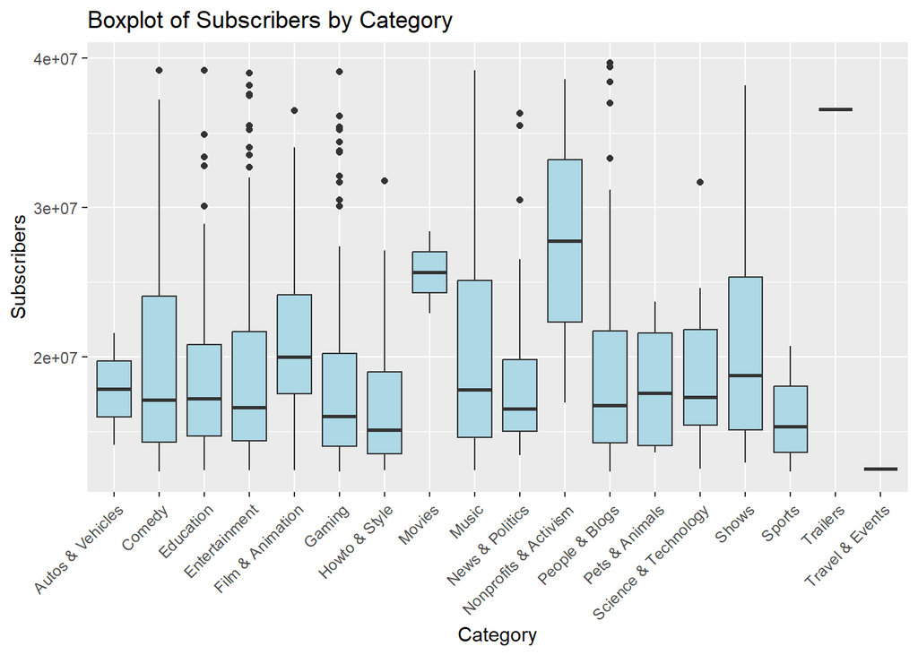

```r
# Remove rows with NaN values in the 'category' column
youtube_cleaned_boxplot <- youtube_cleaned %>%
  filter(!is.na(category))
# Define the remove_outliers function
remove_outliers <- function(x) {
  Q1 <- quantile(x, 0.25)
  Q3 <- quantile(x, 0.75)
  IQR <- Q3 - Q1
  lower_bound <- Q1 - 1.5 * IQR
  upper_bound <- Q3 + 1.5 * IQR
  x_filtered <- replace(x, x < lower_bound | x > upper_bound, NA)
  return(x_filtered)
}
# Apply the remove_outliers function to the 'subscribers' column
youtube_cleaned_boxplot <- youtube_cleaned_boxplot %>%
  mutate(subscribers = remove_outliers(subscribers))
# Create the boxplot for 'subscribers'
ggplot(data = youtube_cleaned_boxplot, aes(x = category, y = subscribers)) +
  geom_boxplot(fill = "lightblue",na.rm = TRUE) +
  labs(x = "Category", y = "Subscribers") +
  ggtitle("Boxplot of Subscribers by Category") +
  theme(axis.text.x = element_text(angle = 45, hjust = 1))
```

This is boxplot of vedio views by category.

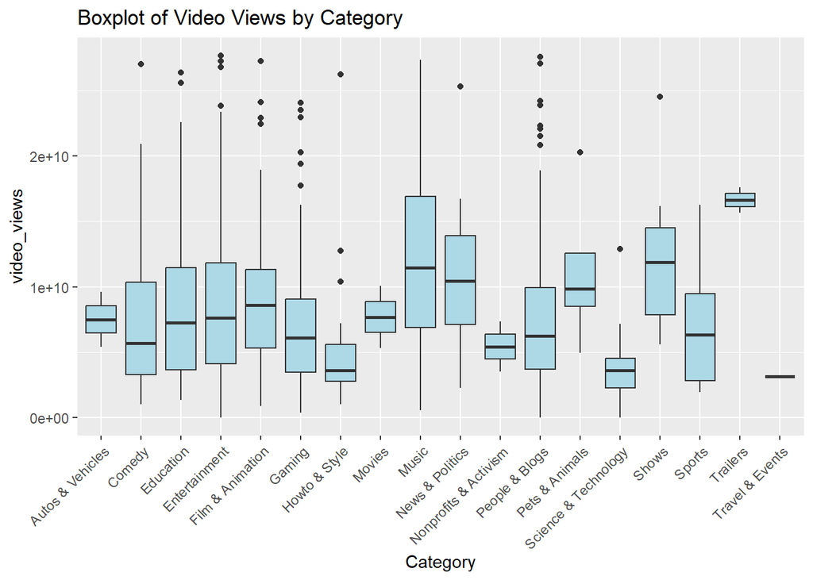

```r
# Filter rows with NaN values in the 'vedio_views' column, Considering that it doesn't make sense to replace the vedio views with the average of other youtuber's vedio views, so a filtered approach is used.
youtube_cleaned_boxplot <- youtube_cleaned %>%
  filter(!is.na(video_views))

# Apply the remove_outliers function to the 'video_views' column
youtube_cleaned_boxplot <- youtube_cleaned_boxplot %>%
  mutate(video_views = remove_outliers(video_views))

# Remove rows with NaN values in the 'category' column again
youtube_cleaned_boxplot <- youtube_cleaned_boxplot %>%
  filter(!is.na(category))

# Create the boxplot for 'video_views'
ggplot(data = youtube_cleaned_boxplot, aes(x = category, y = video_views)) +
    geom_boxplot(fill = "lightblue",na.rm = TRUE) +
    labs(x = "Category", y = "video_views") +
    ggtitle("Boxplot of Video Views by Category") +
    theme(axis.text.x = element_text(angle = 45, hjust = 1))
```

We can see the data distribution for vedio views of different categories, e.g. the median of trailers is the highest.

By initially comparing the distributions of the two boxplots, we estimate that subscribers and vedio views are positively correlated, and we draw a scatterplot of the two below to validate our analysis.

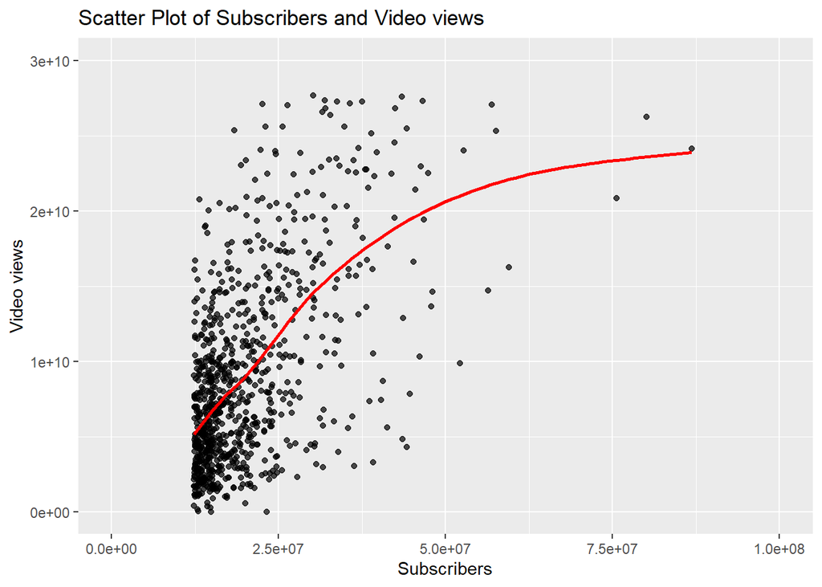

```r
# Handle missing and non-finite values, the reason is it doesn't make sense to replace the vedio views and subscribers with the average of other youtuber's vedio views and subscribers.
youtube_cleaned_boxplot <- youtube_cleaned_boxplot %>%
  filter(!is.na(subscribers) & !is.na(video_views) &
         is.finite(subscribers) & is.finite(video_views))

# Create scatter plot of subscribers and video views
ggplot(youtube_cleaned_boxplot, aes(x = subscribers, y = video_views)) +
  labs(x = "Subscribers", y = "Video views") +
  ggtitle("Scatter Plot of Subscribers and Video views") +
  geom_point(alpha = 0.7, na.rm = TRUE) +
  geom_smooth(method = "loess", se = FALSE, color = "red", na.rm = TRUE) +
  xlim(0, 1.0e+08) +
  ylim(0, 3e+10)
```

From the scatterplot, we can see that subscribers and vedio views are basically positively correlated but there isn’t a strong linear relationship.

## Category and Country

```r
# Set the longitude and latitude limits for filtering
lon_limit <- c(-180, 180)
lat_limit <- c(-90, 90)

# Filter data based on longitude and latitude limits
filtered_data <- youtube_cleaned %>%
  filter(longitude >= lon_limit[1] & longitude <= lon_limit[2] &
           latitude >= lat_limit[1] & latitude <= lat_limit[2])

# Create a leaflet map
heatmap_map <- leaflet(filtered_data) %>%
  addProviderTiles("Stamen.TonerLite") %>%  # Add a map tile provider
  addHeatmap(lng = ~longitude, lat = ~latitude, intensity = 1, radius = 10)  # Add heatmap layer

heatmap_map
```

[interactive chart not shown]

Plot a map, The map shows the main distribution of youtubers, we can see that youtubers are less in Africa. To clearly shows how many the youtubers in different country, we need to plot horizontal bar charts.

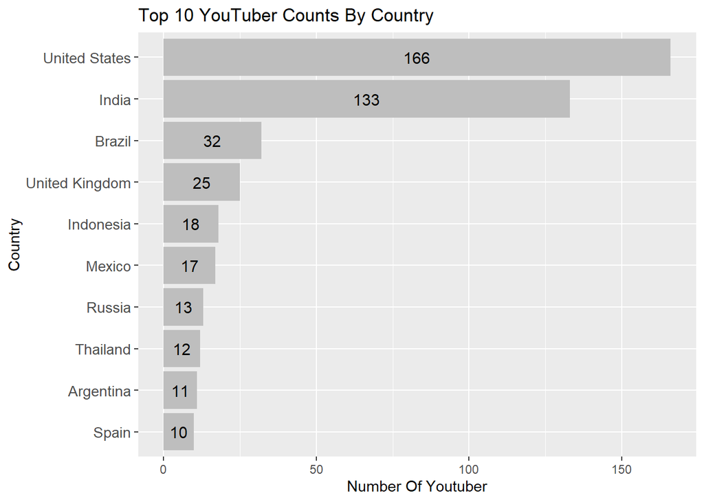

```r
youtube_stats <- youtube_cleaned %>%
  na.omit() %>% # NA does not participate in rankings
  group_by(country) %>%
  summarise(youtuber_count = n())


# Arrange countries by YouTuber count in descending order and select the top 10
youtube_stats <- youtube_stats %>%
  arrange(desc(youtuber_count)) %>%
  head(10)

ggplot(youtube_stats, aes(x = fct_reorder(country, youtuber_count), y = youtuber_count)) +
  geom_bar(stat = "identity", fill = "gray") +
  geom_text(aes(label = comma(youtuber_count)), position = position_stack(vjust = 0.5), size = 4) +
  ggtitle("Top 10 YouTuber Counts By Country") +
  coord_flip() +
  labs(x = "Country", y = "Number Of Youtuber") +
  theme(axis.text.y = element_text(size = rel(1.2)))
```

We can see most youtubers are in US and India, but to further study the categories of youtubers in different countries, you need to draw heat maps to show the frequency distribution of the categories.

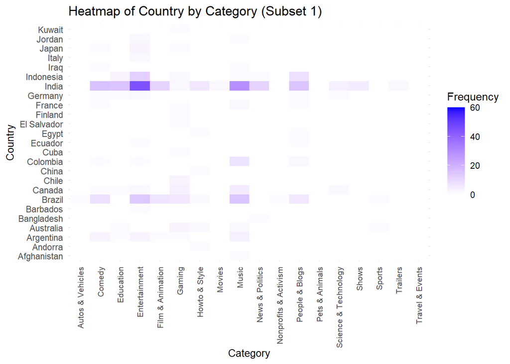

```r
category_country_table <- table(youtube_cleaned$category, youtube_cleaned$country)
category_country_df <- as.data.frame(category_country_table)

# Get unique country names from the dataset
unique_countries <- unique(category_country_df$Var2)
# Define the number of countries in each subset
subset_size <- ceiling(length(unique_countries) / 2)
# Split the unique country names into two subsets,because of the large volume of countries
countries_subset1 <- unique_countries[1:subset_size]
countries_subset2 <- unique_countries[(subset_size + 1):length(unique_countries)]
# Filter data for each subset
category_country_df1 <- category_country_df[category_country_df$Var2 %in% countries_subset1, ]
category_country_df2 <- category_country_df[category_country_df$Var2 %in% countries_subset2, ]
# Create heatmaps dynamically
heatmap1 <- ggplot(category_country_df1, aes(x = Var1, y = Var2, fill = Freq)) +
  geom_tile() +
  scale_fill_gradient(low = "white", high = "blue", limits = c(0, 60),breaks = seq(0, 60, by = 20)) +
  labs(x = "Category", y = "Country", fill = "Frequency") +
  ggtitle("Heatmap of Country by Category (Subset 1)") +
  theme_minimal() +
  theme(
    axis.text.x = element_text(angle = 90, hjust = 1, vjust = 0.5, size = 8),
    axis.title.x = element_text(size = 10),
    axis.title.y = element_text(size = 10),
  )
heatmap1
```

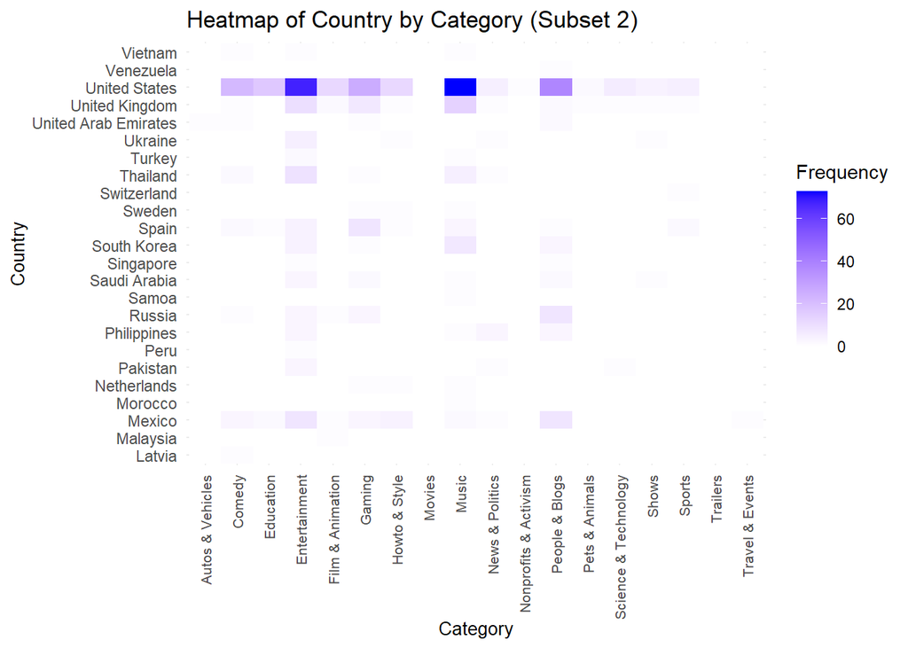

```r
heatmap2 <- ggplot(category_country_df2, aes(x = Var1, y = Var2, fill = Freq)) +
  geom_tile() +
  scale_fill_gradient(low = "white", high = "blue") +
  labs(x = "Category", y = "Country", fill = "Frequency") +
  ggtitle("Heatmap of Country by Category (Subset 2)") +
  theme_minimal() +
  theme(
    axis.text.x = element_text(angle = 90, hjust = 1, vjust = 0.5, size = 8),
    axis.title.x = element_text(size = 10),
    axis.title.y = element_text(size = 10),
  )
heatmap2
```